# Douglas Fir (Fd)

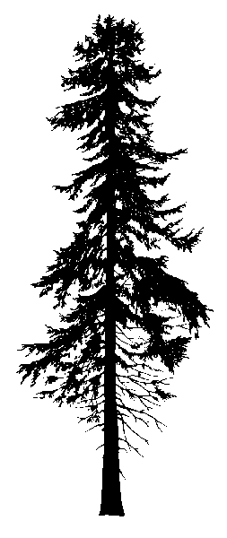

Douglas Fir (*Pseudotsuga menziesii*)

**Douglas-fir (abbreviated as Fd) is one of the most prevalent and valuable tree species in British Columbia. The CCISS model predicts warmer temperatures will facilitate increased suitability of Fd throughout much of its current range and expansion of suitable range at higher elevations and further north, especially on mesic and drier sites. Fd is predicted to become less suitable in the hottest and driest sites, i.e. valley bottoms of the Southern Interior.**

While the CCISS tool offers valuable insights into broad-scale trends, summarized here by species, suitability projections must be interpreted with caution. Many areas of projected change are also areas with high uncertainty in climate predictions. Furthermore, factors such as soil texture, drainage, land-use history, forest health pressures, and biotic interactions (e.g., competition or browsing) can strongly influence actual outcomes on the ground. These nuances emphasize the importance of pairing climate tools with on-the-ground knowledge and site-specific judgement when planning future Douglas-fir management.

**Species geographic and climatic range**

Douglas-fir (Fd) is native to the Pacific and Cordilleran regions of Western North America. In BC there are two varieties, interior Douglas-fir (*Pseudotsuga menziesii* var. *glauca*) found throughout the Central and Southern Interior and coastal Douglas-fir (*Pseudotsuga menziesii* var. *menziesii*) found along the south coast and Vancouver Island. It is most common in the montane zone, but also occurs in the submontane zone and to a lesser extent subalpine zone (Klinka et al., 2000).

Fd is best adapted to cool/warm temperate and cool (warm) mesothermal climates (Klinka et al., 2000), occurring from the humid maritime coastal climate to the semi-arid continental climate of the interior. The distribution of Fd in the interior of BC represents its northernmost latitudinal range, limited by cold temperatures. Fd is also limited by high-elevation and forest-grassland transitions (Griesbauer & Green, 2010).

The growth response of Fd to climate varies over the species’ broad geographic and climatic range. Fd populations growing in relatively warm and dry climates are limited by growing season precipitation and water availability (Case & Peterson, 2005; Griesbauer & Green, 2010; Watson & Luckman, 2002), with trees on drier stands having greater sensitivity to drought conditions (Adams & Kolb, 2005). Meanwhile, Fd populations growing in high-elevation wet and cold climates are limited by snowfall, and cold annual and winter temperatures (Case & Peterson, 2005; Griesbauer & Green, 2010).

Fd has a wide ecological amplitude, but is most commonly found on moderately dry to slightly dry sites with medium soil nutrients (Klinka et al., 2000). Fd is found on a variety of soil types, but grows best on deep well-drained, sandy loams where moisture in the soil is plentiful.

Fd is commonly a pioneer species that regenerates after forest fires, logging or other disturbances, forming single-species even-aged stands. It is also found in un-even aged stands or in mixed-species stands, often with western hemlock, western redcedar, trembling aspen, ponderosa pine, lodgepole pine, or western larch (Klinka et al., 2000). Fd is a major component in old-growth forests in boreal, cool temperate and cool mesothermal climates.

**Species environmental suitability during the reference period (1961–1990)**

In the maps below, each colour represents the species environmental suitability during the historical reference period* of 1961-90 as determined by expert ratings. Green represents a high suitability (E1 rating), blue represents moderate suitability (E2), yellow represents low suitability (E3), and white indicates areas that are unsuitable for the species. See [CCISS Documentation tab > Methods > Environmental Suitability Ratings](https://bcgov-ffec.ca/cciss-docs/Methods.html#environmental-suitability-ratings) for more detailed definitions and information on the expert rating process.

*Note on terminology: The historical reference period is sometimes referred to as the “baseline” or simply “historical” or “reference” period.

**Medium/mesic (C4)**

Environmental suitability in medium/mesic (C4) edatopes under baseline climate (1961-1990)

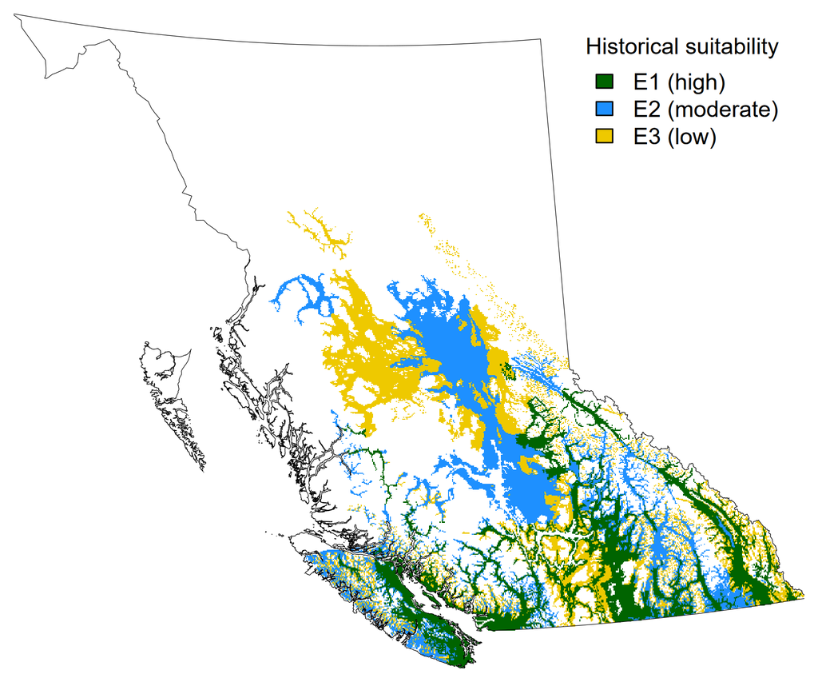

On medium/mesic sites Fd environmental suitability is high (E1) in the southern low elevation CWH subzones, mid slopes of the Southern Interior, and valley bottoms of the Columbia Mountains, Cariboo Mountains and Rocky Mountain Trench. Suitability is moderate (E2) throughout much of the Central Interior and above the E1 area in the south and southeast. Suitability is low (E3) on the Nechako Plateau and at the margins of E2 suitability throughout.

**Poor/subxeric (B2)**

Environmental suitability in poor/subxeric (B2) edatopes under baseline climate (1961-1990)

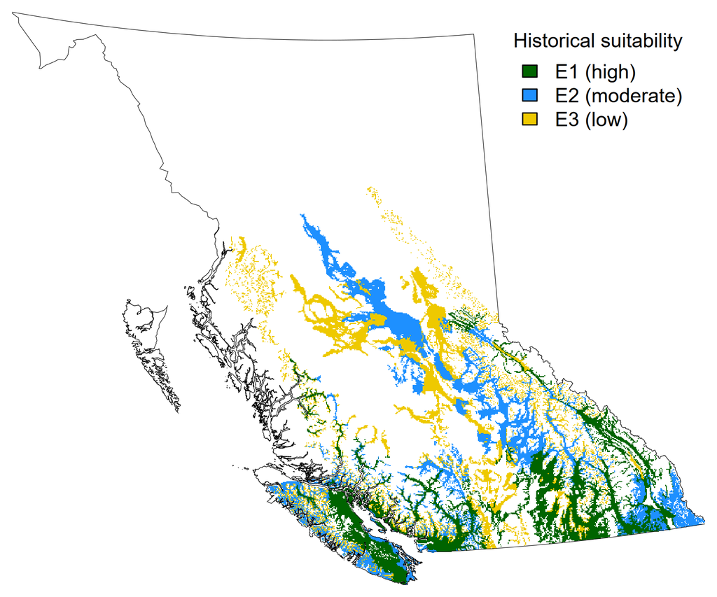

On poor/subxeric sites Fd environmental suitability is moderate to low (E2 to E3) throughout the Central and Southern Interior. Suitability is high (E1) bordering the Strait of Georgia and on the lower slopes of the southern Columbia Mountains and Rocky Mountain Trench.

**Rich/hygric (D6)**

Environmental suitability in rich/hygric (D6) edatopes under baseline climate (1961-1990)

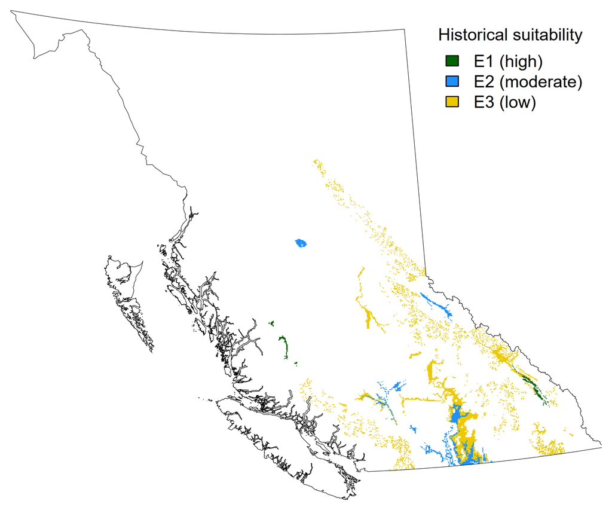

**Distribution of Fd across BGC zones**

The pie chart to the right depicts the distribution of the total environmentally suitable area of Fd in BC by biogeoclimatic (BGC) zone, based on the climate of the historical reference period (1961–1990).

In the interior, Fd is a key species in the southern subzones of the Interior Cedar-Hemlock (ICH) and Sub-Boreal Spruce (SBS) zones, and dominates the Interior Douglas-fir (IDF) zone. It can also be found in the Montane Spruce (MS) and the lower southern Engelmann Spruce – Subalpine Fir (ESSF) zones ([Government of British Columbia 2025](https://www2.gov.bc.ca/gov/content/industry/forestry/managing-our-forest-resources/silviculture/tree-species-selection/tree-species-compendium-index/douglas-fir)).

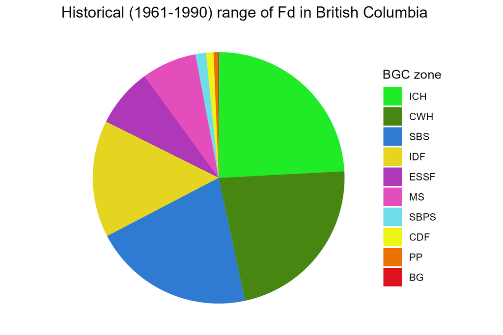

**Key to BGC zones:** [CCISS Documentation > Definitions](https://bcgov-ffec.ca/cciss-docs/Definitions.html#biogeoclimatic-ecosystem-classification-bec-codes)

**Future projected environmental suitability for Douglas-fir**

On this page, you will find a visual and interpretive synthesis of the environmental suitability projections calculated using the Climate Change Informed Species Selection [CCISS](https://bcgov-ffec.ca/cciss-docs/) tool, including:

1. Proportion of the historic range that the species is predicted to remain environmentally suitable (i.e. persist) or become newly suitable (i.e. expand) by site type (edatope).
2. Predicted mean changes in environmental suitability across its geographic range in BC, by future time period and site type (edatope).
3. Predicted shifts in total suitable area over time across the province and by biogeoclimatic (BGC) zone.

**Broad trends**

*Notes on interpretation of persistence and expansion*

Persistence (x-axis) and expansion (y-axis) are subtly different in how they relate to the historical range of the species. Persistence describes the change in environmental suitability within the species historical range. While Expansion describes the change in environmental suitability outside of the species historical range. Calculated as follows:

$$\text{Persistence (\%)} =
\frac{\text{future suitable area within historical range of suitability}}
{\text{historically suitable area}}
\times 100$$
$$\text{Expansion (\%)} =
\frac{\text{future suitable area outside historical range of suitability}}
{\text{historically suitable area}}
\times 100$$

**Mesic/zonal (C4)**

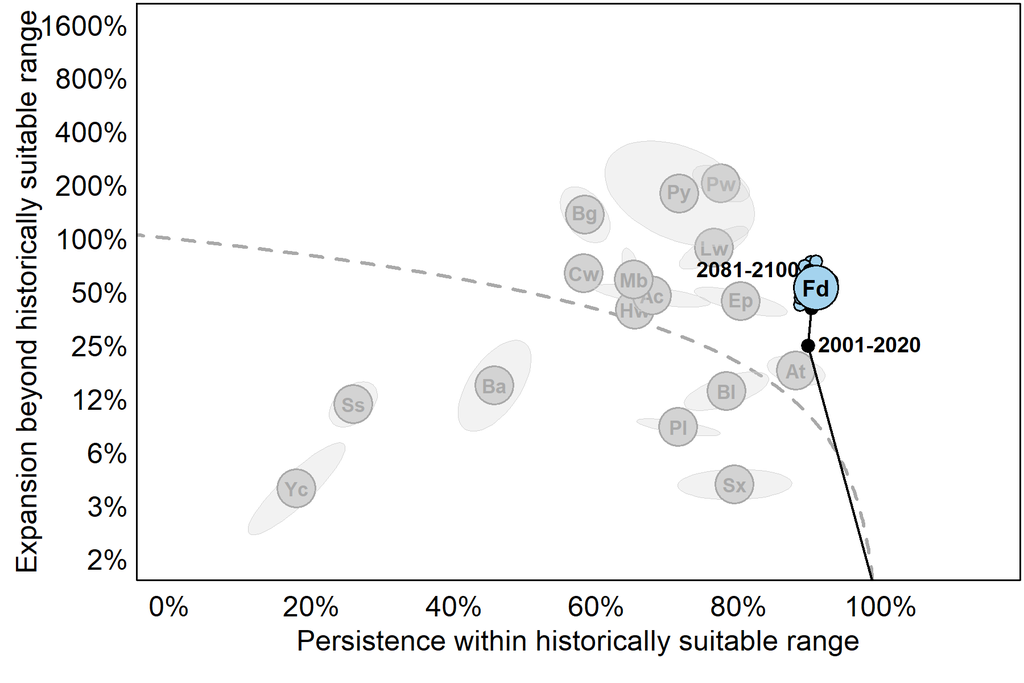

Projected persistence and expansion of the suitable range of Fd in the SSP2–4.5 emission scenario given current policies for moderate emission mitigation. The black line shows the projected trajectory of change over time, with black points representing an average for each time period (first and last time periods are labeled). The model results for the 2041–2060 period are depicted in blue due to the relevance of this time period for management planning. The small blue points represent simulation runs of the various global climate models (GCMs) used in the CCISS projections and the large blue point with species abbreviation is the mean (Mahony et al., 2022). Other species are shown for reference as grey mean points and shaded ellipses representing the 1-standard deviation probability of the ensemble calculated for each point. The grey dashed line divides areas of the plot for which total suitable area is either growing (above the line) or shrinking (below the line). Note that all results exclude biogeoclimatic units that do not currently support commercially operable forest, and that expansion (the y-axis) is log-scaled.

**Poor/subxeric (B2)**

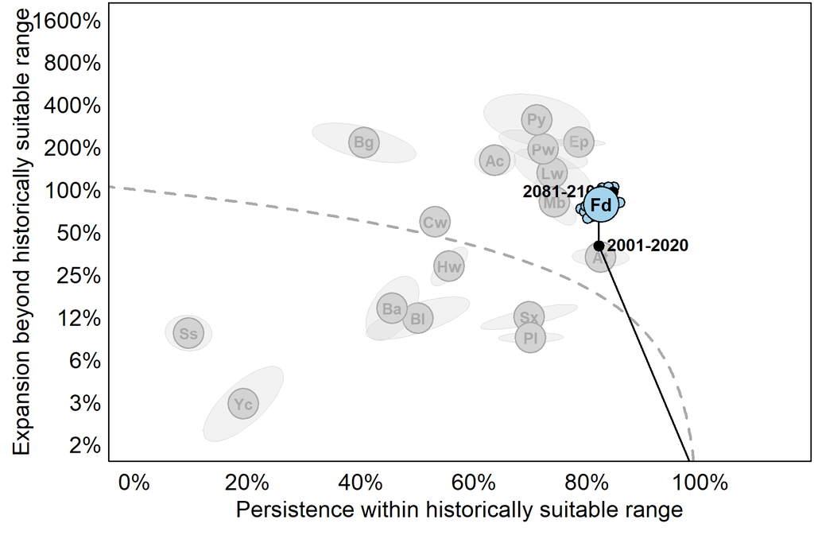

Projected persistence and expansion of the suitable range of Fd in the SSP2–4.5 emission scenario given current policies for moderate emission mitigation. The black line shows the projected trajectory of change over time, with black points representing an average for each time period (first and last time periods are labeled). The model results for the 2041–2060 period are depicted in blue due to the relevance of this time period for management planning. The small blue points represent simulation runs of the various global climate models (GCMs) used in the CCISS projections and the large blue point with species abbreviation is the mean (Mahony et al., 2022). Other species are shown for reference as grey mean points and shaded ellipses representing the 1-standard deviation probability of the ensemble calculated for each point. The grey dashed line divides areas of the plot for which total suitable area is either growing (above the line) or shrinking (below the line). Note that all results exclude biogeoclimatic units that do not currently support commercially operable forest, and that expansion (the y-axis) is log-scaled.

**Rich/hygric (D6)**

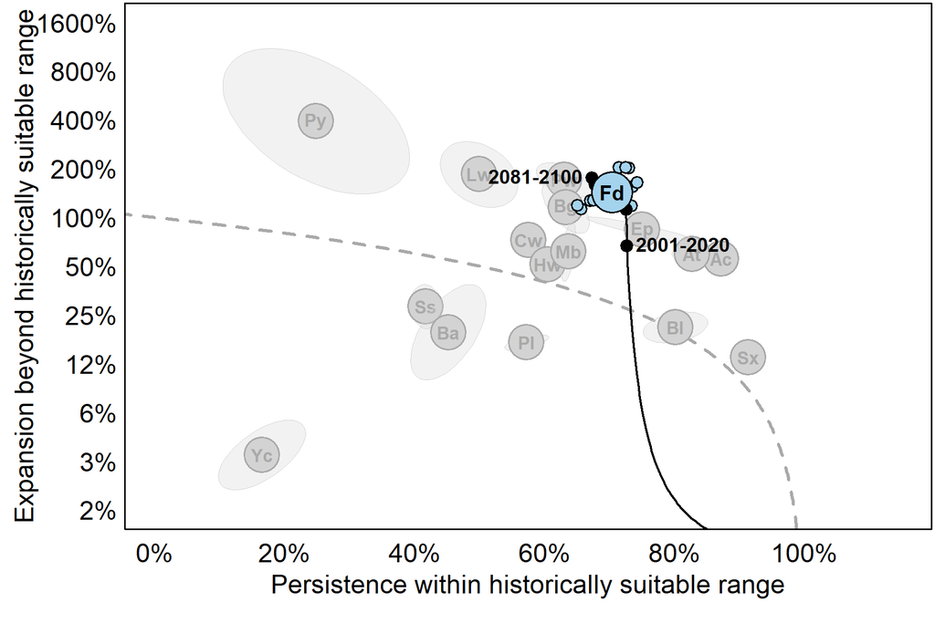

Projected persistence and expansion of the suitable range of Fd in the SSP2–4.5 emission scenario given current policies for moderate emission mitigation. The black line shows the projected trajectory of change over time, with black points representing an average for each time period (first and last time periods are labeled). The model results for the 2041–2060 period are depicted in blue due to the relevance of this time period for management planning. The small blue points represent simulation runs of the various global climate models (GCMs) used in the CCISS projections and the large blue point with species abbreviation is the mean (Mahony et al., 2022). Other species are shown for reference as grey mean points and shaded ellipses representing the 1-standard deviation probability of the ensemble calculated for each point. The grey dashed line divides areas of the plot for which total suitable area is either growing (above the line) or shrinking (below the line). Note that all results exclude biogeoclimatic units that do not currently support commercially operable forest, and that expansion (the y-axis) is log-scaled.

**Suitability changes**

Overall, the CCISS model predicts warmer temperatures will facilitate increased suitability of Fd across the province. The total area suitable for Fd is projected to increase with climate change, however large areas of the hottest/driest portions of its historical range are projected to become unsuitable.

The suitable range of Fd is projected to expand (yellow shades on the maps) at higher elevation and further north, especially on mesic (C4) and drier (B2) site types. Major increases in suitability occur east of the coast transition, in the Central Interior, Sub-boreal Interior, in the Boreal Plains, and on Haida Gwaii. Increasing Fd suitability throughout much of the interior is driven by a shift to Interior Douglas-fir (IDF) and Interior Cedar Hemlock (ICH) climate conditions. However, cold air and frost is likely still a hazard.

The CCISS model predicts a loss of Fd suitability at low elevation in the Okanagan Valley, Central Interior, Rocky Mountain Trench, and Chilcotin River Valley. These declines in suitability are driven by warmer temperatures creating drought conditions in these low elevation valley bottoms. The climate is shifting to that characterizing Bunchgrass (BG) units and will not support Fd.

There is lower confidence in the loss of Fd suitability on rich/hygric (D6) sites around Prince George and in the Central Interior. This is possibly an artefact of the BGC climate futures that are projected. Climate models predict warmer, wetter conditions. We would expect Fd to remain suitable on wet sites under warmer-wetter conditions. See the CCISS Tool Documentation for more information on how [BGC projections](https://bcgov-ffec.ca/cciss-docs/Methods.html) work and the [sources of error](https://bcgov-ffec.ca/cciss-docs/Issues.html).

These patterns are shown in 20-year intervals and by edatopic space in the figures to the right.

**Medium/mesic (C4)**

**2001–2020**

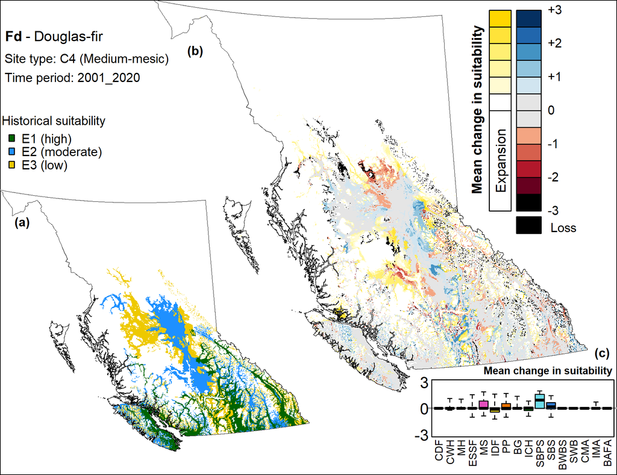

a) Historical environmental suitability rating during the reference period of 1961–1990 as determined by expert ratings.  
b) Mean change in suitability from the reference period, with shades of yellow representing areas of new suitability, blue shades representing increased suitability, red shades representing decreased suitability, and black representing a complete loss of suitability.  
c) Mean changes in suitability ranking by BGC zone; boxplot whiskers extend to the 5th and 95th percentiles.

**2021–2040**

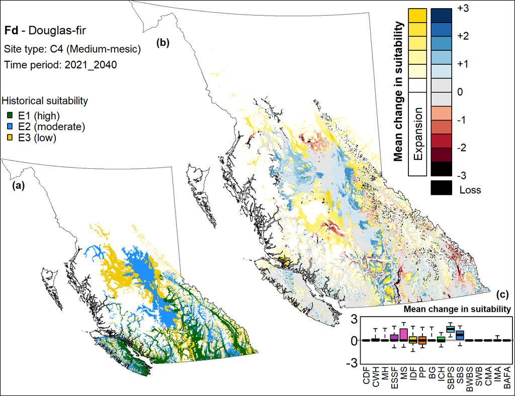

a) Historical environmental suitability rating during the reference period of 1961–1990 as determined by expert ratings.  
b) Mean change in suitability from the reference period, with shades of yellow representing areas of new suitability, blue shades representing increased suitability, red shades representing decreased suitability, and black representing a complete loss of suitability.  
c) Mean changes in suitability ranking by BGC zone; boxplot whiskers extend to the 5th and 95th percentiles.

**2041–2060**

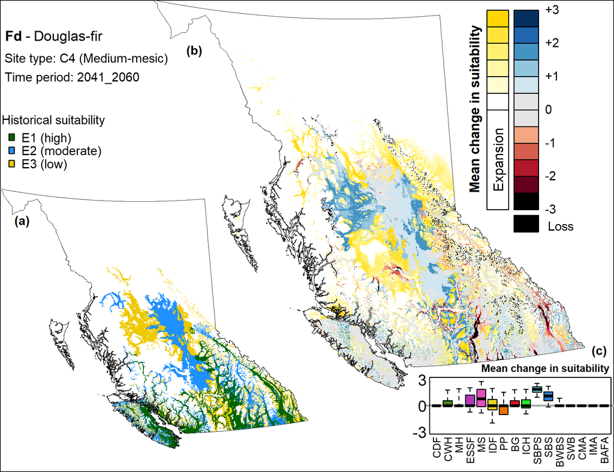

a) Historical environmental suitability rating during the reference period of 1961–1990 as determined by expert ratings.  
b) Mean change in suitability from the reference period, with shades of yellow representing areas of new suitability, blue shades representing increased suitability, red shades representing decreased suitability, and black representing a complete loss of suitability.  
c) Mean changes in suitability ranking by BGC zone; boxplot whiskers extend to the 5th and 95th percentiles.

**2061–2080**

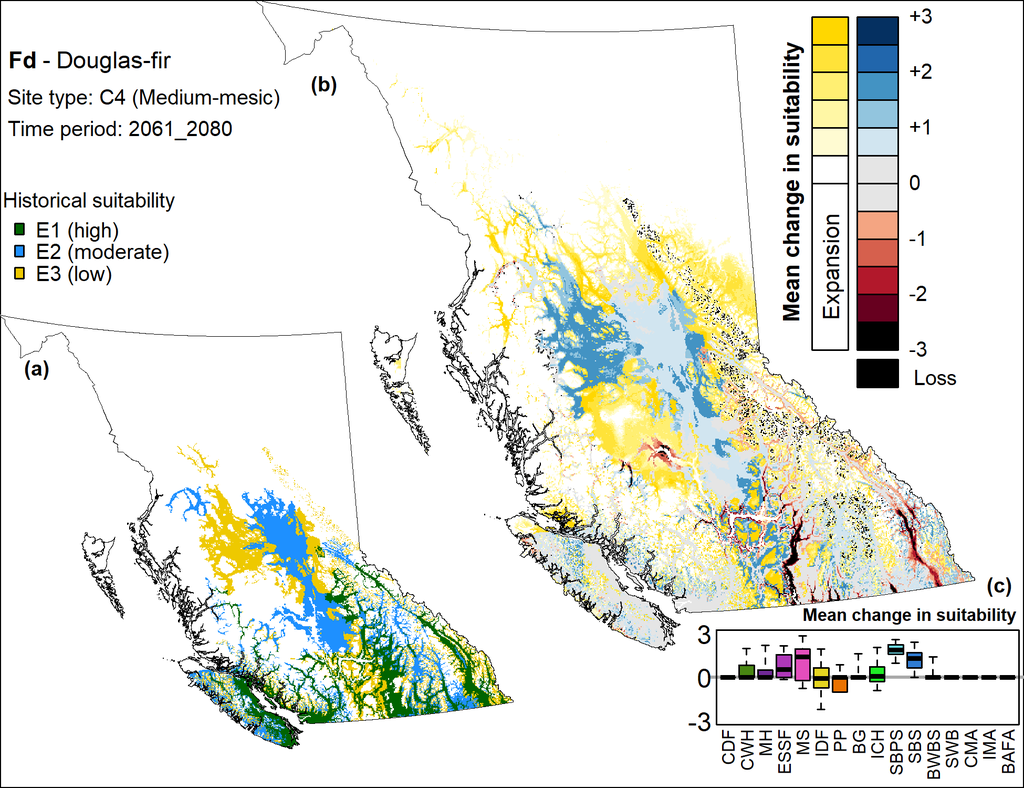

a) Historical environmental suitability rating during the reference period of 1961–1990 as determined by expert ratings.  
b) Mean change in suitability from the reference period, with shades of yellow representing areas of new suitability, blue shades representing increased suitability, red shades representing decreased suitability, and black representing a complete loss of suitability.  
c) Mean changes in suitability ranking by BGC zone; boxplot whiskers extend to the 5th and 95th percentiles.

**2081–2100**

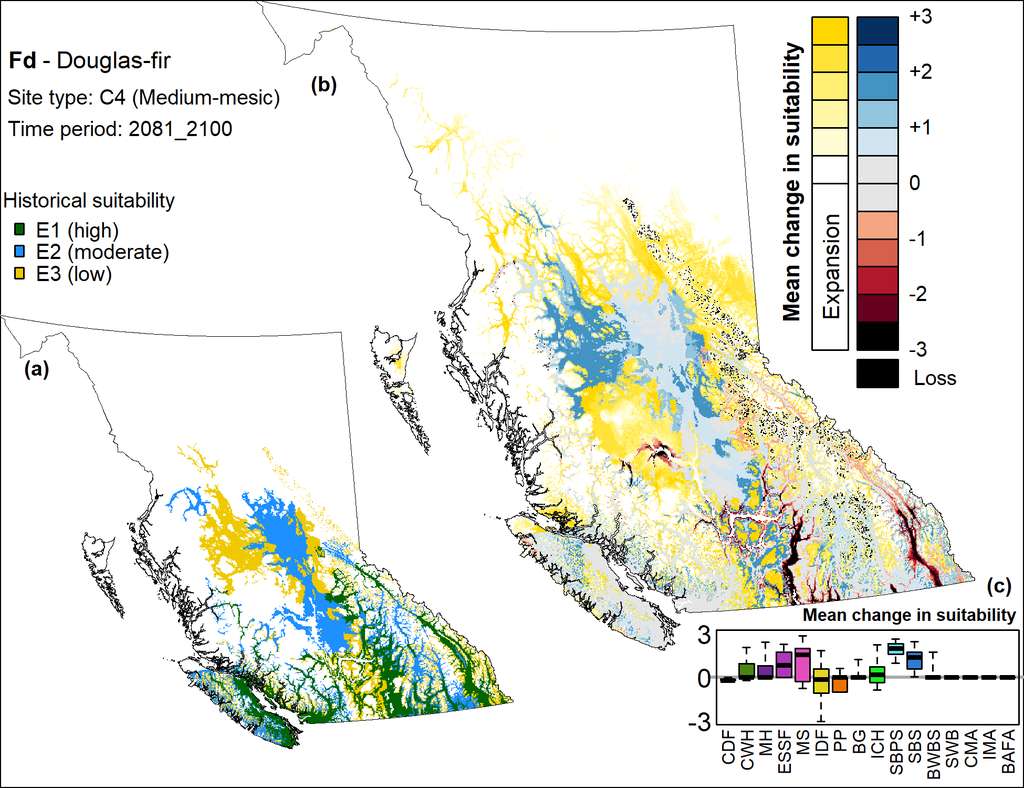

a) Historical environmental suitability rating during the reference period of 1961–1990 as determined by expert ratings.  
b) Mean change in suitability from the reference period, with shades of yellow representing areas of new suitability, blue shades representing increased suitability, red shades representing decreased suitability, and black representing a complete loss of suitability.  
c) Mean changes in suitability ranking by BGC zone; boxplot whiskers extend to the 5th and 95th percentiles.

**Poor/subxeric (B2)**

**2001–2020**

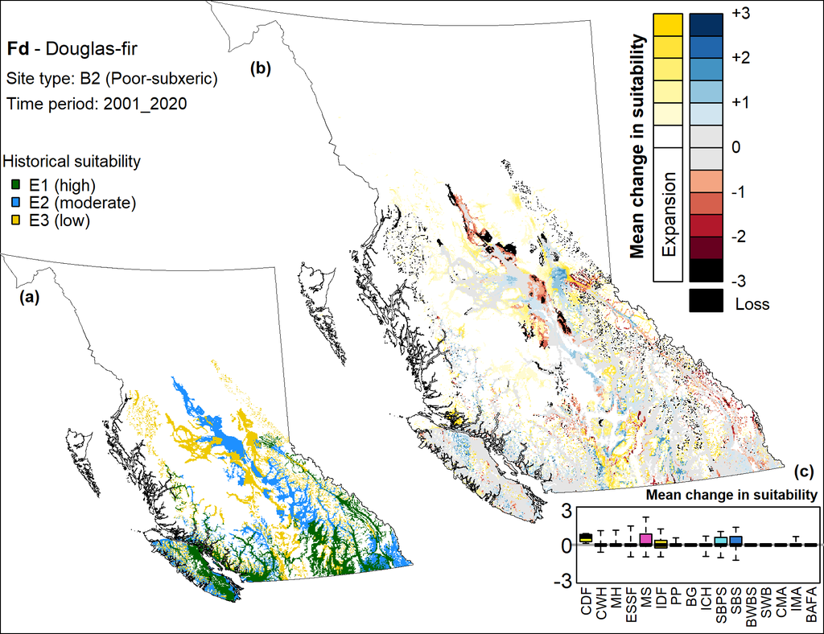

a) Historical environmental suitability rating during the reference period of 1961–1990 as determined by expert ratings.  
b) Mean change in suitability from the reference period, with shades of yellow representing areas of new suitability, blue shades representing increased suitability, red shades representing decreased suitability, and black representing a complete loss of suitability.  
c) Mean changes in suitability ranking by BGC zone; boxplot whiskers extend to the 5th and 95th percentiles.

**2021–2040**

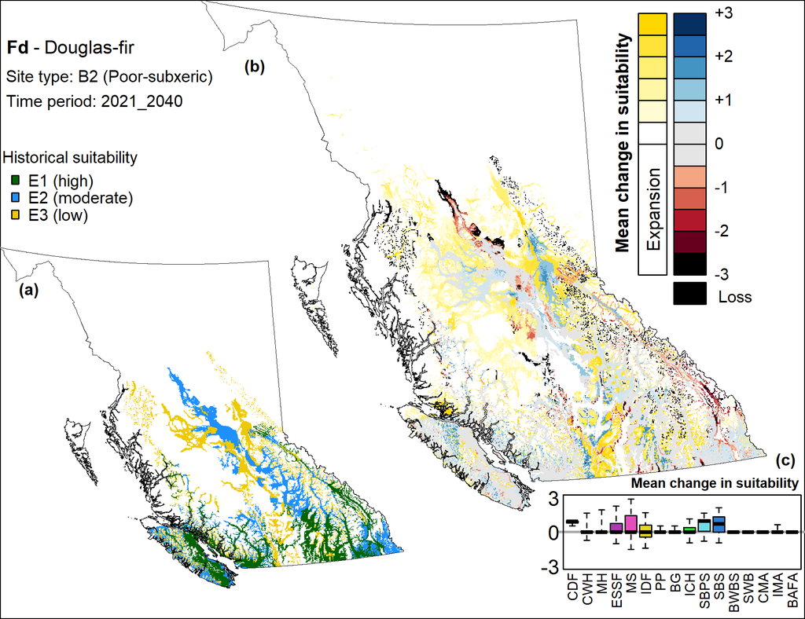

a) Historical environmental suitability rating during the reference period of 1961–1990 as determined by expert ratings.  
b) Mean change in suitability from the reference period, with shades of yellow representing areas of new suitability, blue shades representing increased suitability, red shades representing decreased suitability, and black representing a complete loss of suitability.  
c) Mean changes in suitability ranking by BGC zone; boxplot whiskers extend to the 5th and 95th percentiles.

**2041–2060**

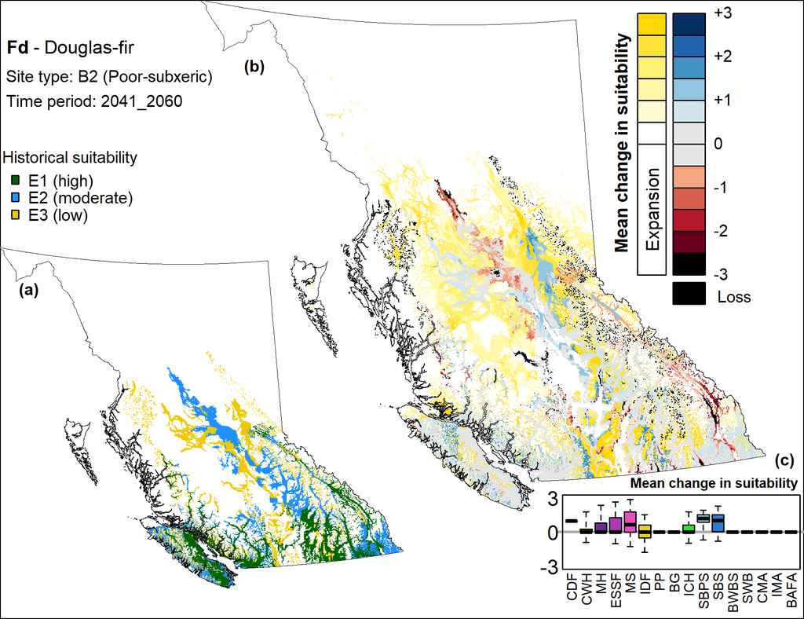

a) Historical environmental suitability rating during the reference period of 1961–1990 as determined by expert ratings.  
b) Mean change in suitability from the reference period, with shades of yellow representing areas of new suitability, blue shades representing increased suitability, red shades representing decreased suitability, and black representing a complete loss of suitability.  
c) Mean changes in suitability ranking by BGC zone; boxplot whiskers extend to the 5th and 95th percentiles.

**2061–2080**

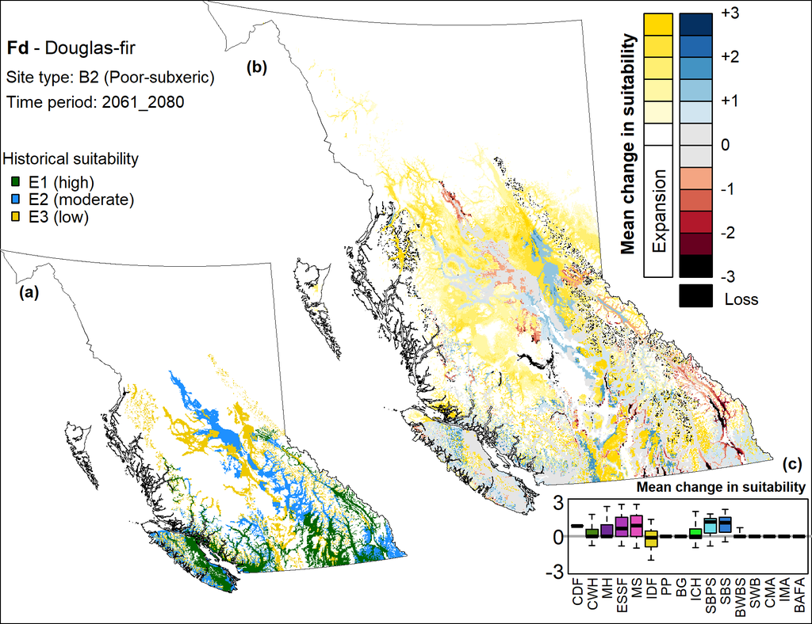

a) Historical environmental suitability rating during the reference period of 1961–1990 as determined by expert ratings.  
b) Mean change in suitability from the reference period, with shades of yellow representing areas of new suitability, blue shades representing increased suitability, red shades representing decreased suitability, and black representing a complete loss of suitability.  
c) Mean changes in suitability ranking by BGC zone; boxplot whiskers extend to the 5th and 95th percentiles.

**2081–2100**

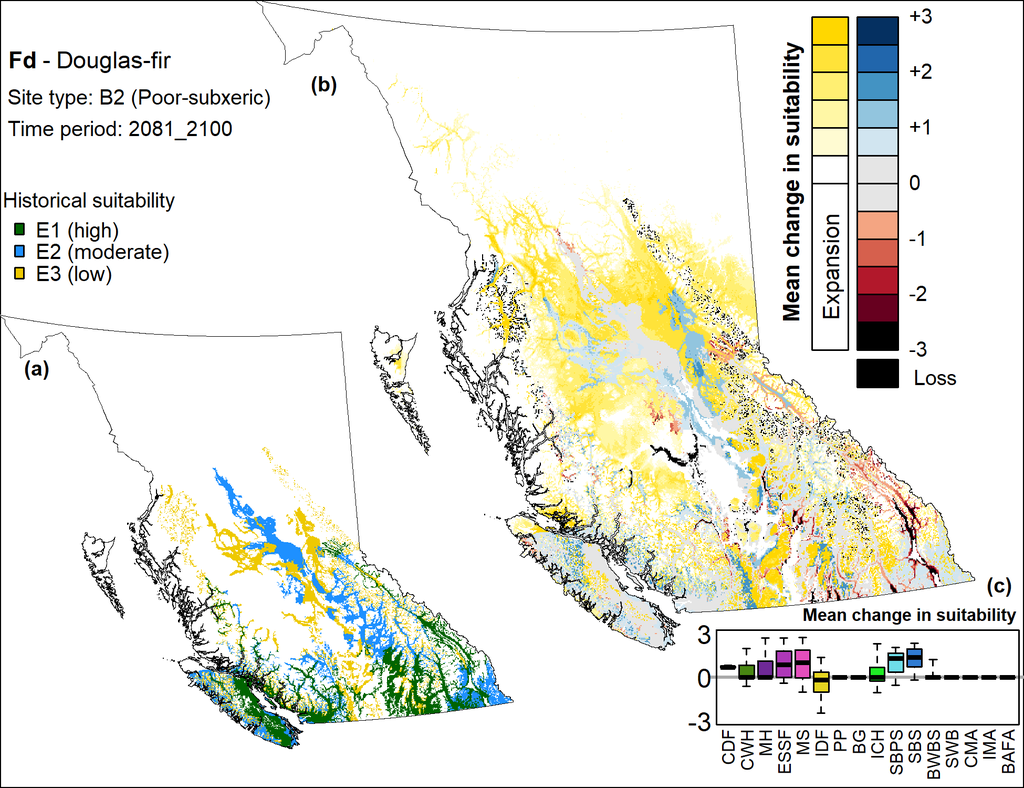

a) Historical environmental suitability rating during the reference period of 1961–1990 as determined by expert ratings.  
b) Mean change in suitability from the reference period, with shades of yellow representing areas of new suitability, blue shades representing increased suitability, red shades representing decreased suitability, and black representing a complete loss of suitability.  
c) Mean changes in suitability ranking by BGC zone; boxplot whiskers extend to the 5th and 95th percentiles.

**Rich/hygric (D6)**

**2001–2020**

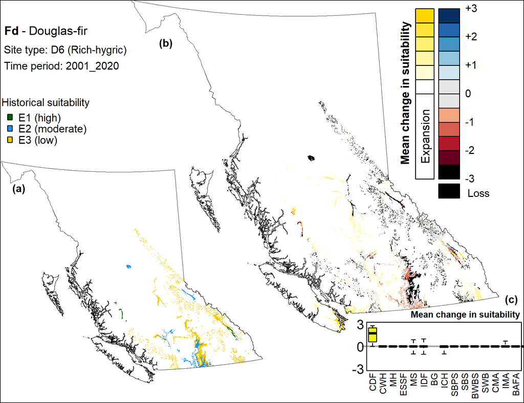

a) Historical environmental suitability rating during the reference period of 1961–1990 as determined by expert ratings.  
b) Mean change in suitability from the reference period, with shades of yellow representing areas of new suitability, blue shades representing increased suitability, red shades representing decreased suitability, and black representing a complete loss of suitability.  
c) Mean changes in suitability ranking by BGC zone; boxplot whiskers extend to the 5th and 95th percentiles.

**2021–2040**

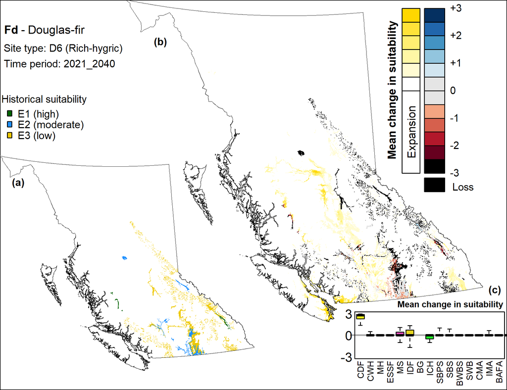

a) Historical environmental suitability rating during the reference period of 1961–1990 as determined by expert ratings.  
b) Mean change in suitability from the reference period, with shades of yellow representing areas of new suitability, blue shades representing increased suitability, red shades representing decreased suitability, and black representing a complete loss of suitability.  
c) Mean changes in suitability ranking by BGC zone; boxplot whiskers extend to the 5th and 95th percentiles.

**2041–2060**

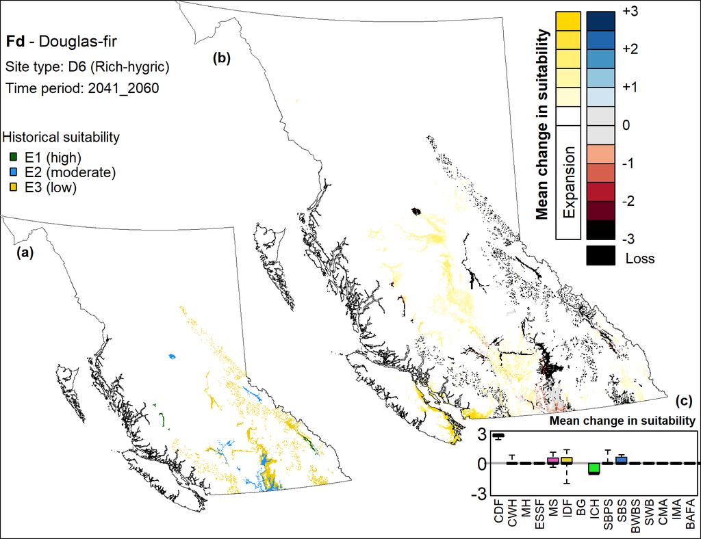

a) Historical environmental suitability rating during the reference period of 1961–1990 as determined by expert ratings.  
b) Mean change in suitability from the reference period, with shades of yellow representing areas of new suitability, blue shades representing increased suitability, red shades representing decreased suitability, and black representing a complete loss of suitability.  
c) Mean changes in suitability ranking by BGC zone; boxplot whiskers extend to the 5th and 95th percentiles.

**2061–2080**

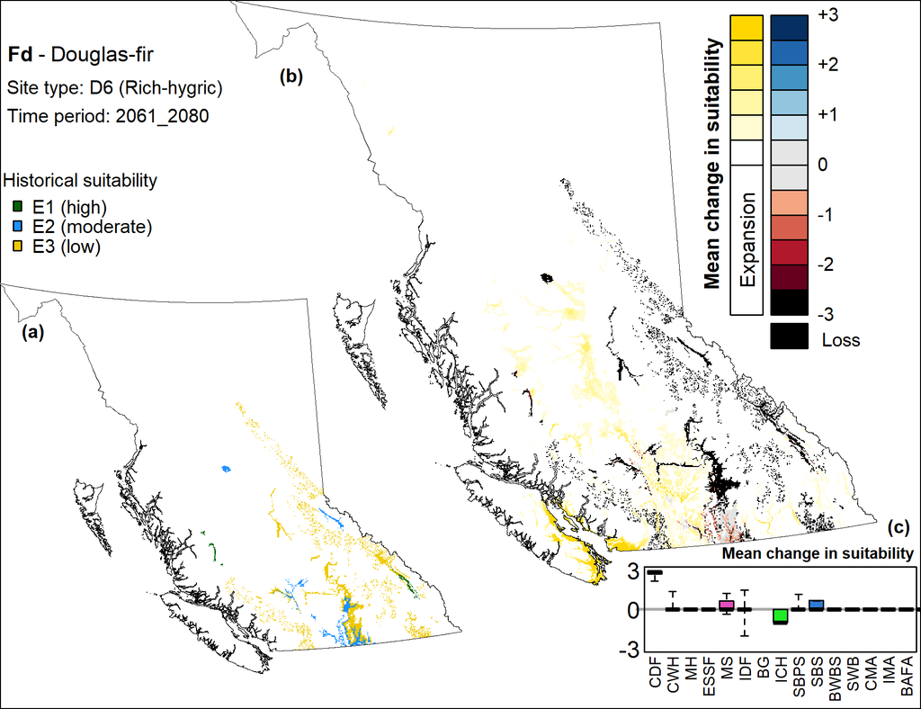

a) Historical environmental suitability rating during the reference period of 1961–1990 as determined by expert ratings.  
b) Mean change in suitability from the reference period, with shades of yellow representing areas of new suitability, blue shades representing increased suitability, red shades representing decreased suitability, and black representing a complete loss of suitability.  
c) Mean changes in suitability ranking by BGC zone; boxplot whiskers extend to the 5th and 95th percentiles.

**2081–2100**

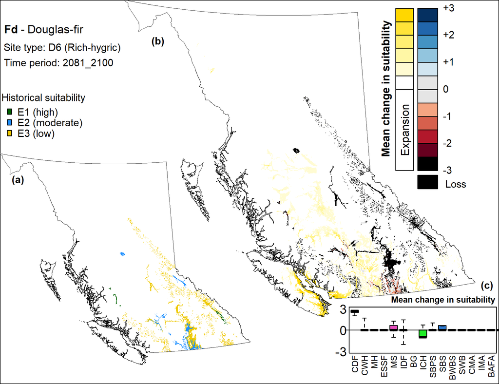

a) Historical environmental suitability rating during the reference period of 1961–1990 as determined by expert ratings.  
b) Mean change in suitability from the reference period, with shades of yellow representing areas of new suitability, blue shades representing increased suitability, red shades representing decreased suitability, and black representing a complete loss of suitability.  
c) Mean changes in suitability ranking by BGC zone; boxplot whiskers extend to the 5th and 95th percentiles.

**Shifts in suitable area**

**Medium/mesic (C4)**

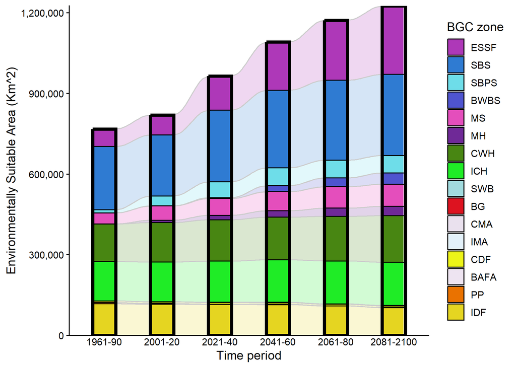

This figure shows the projected changes in Fd’s suitable area in BC (km<sup>2</sup>) over time by biogeoclimatic zone (colours) within the three representative site types/edatopes (tabs). The first time period shown on the left of each graph is the historical reference period (1961–1990), where environmental suitability is determined by expert ratings. Subsequent time periods are based on CCISS model projections incorporating environmental suitability (from the reference period) and future climate data. For future projected time periods, the relative areas of BGC zones remain static within the province (i.e., they are not shrinking or growing). Rather, this figure reflects changes in the projected spatial distribution of climate types that may be more or less suitable for the focal species, representing changes in suitable area across these static zones.

**Key to BGC zones:** [CCISS Documentation > Definitions](https://bcgov-ffec.ca/cciss-docs/Definitions.html#biogeoclimatic-ecosystem-classification-bec-codes)

**Poor/subxeric (B2)**

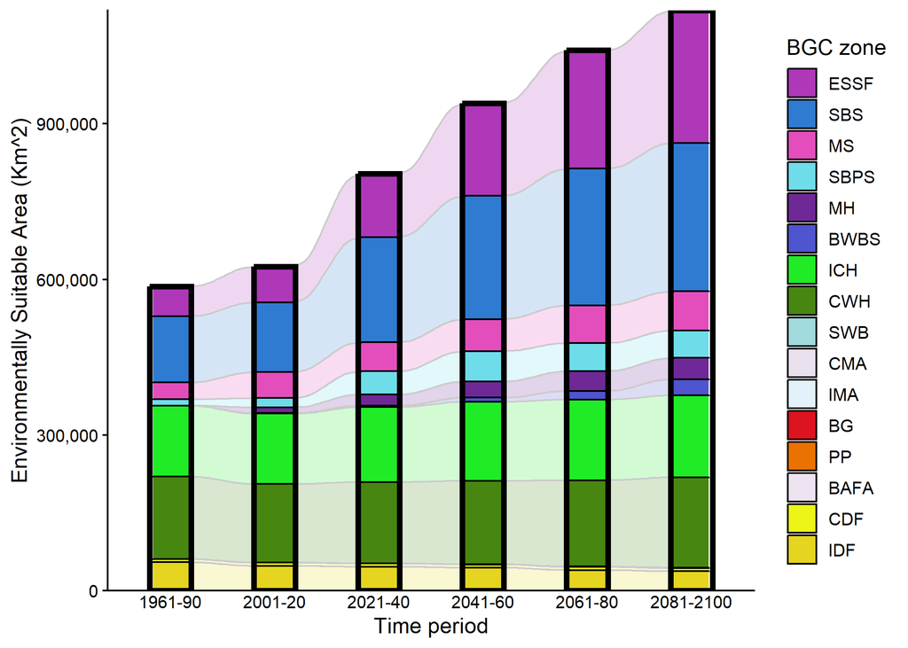

This figure shows the projected changes in Fd’s suitable area in BC (km<sup>2</sup>) over time by biogeoclimatic zone (colours) within the three representative site types/edatopes (tabs). The first time period shown on the left of each graph is the historical reference period (1961–1990), where environmental suitability is determined by expert ratings. Subsequent time periods are based on CCISS model projections incorporating environmental suitability (from the reference period) and future climate data. For future projected time periods, the relative areas of BGC zones remain static within the province (i.e., they are not shrinking or growing). Rather, this figure reflects changes in the projected spatial distribution of climate types that may be more or less suitable for the focal species, representing changes in suitable area across these static zones.

**Key to BGC zones:** [CCISS Documentation > Definitions](https://bcgov-ffec.ca/cciss-docs/Definitions.html#biogeoclimatic-ecosystem-classification-bec-codes)

**Rich/hygric (D6)**

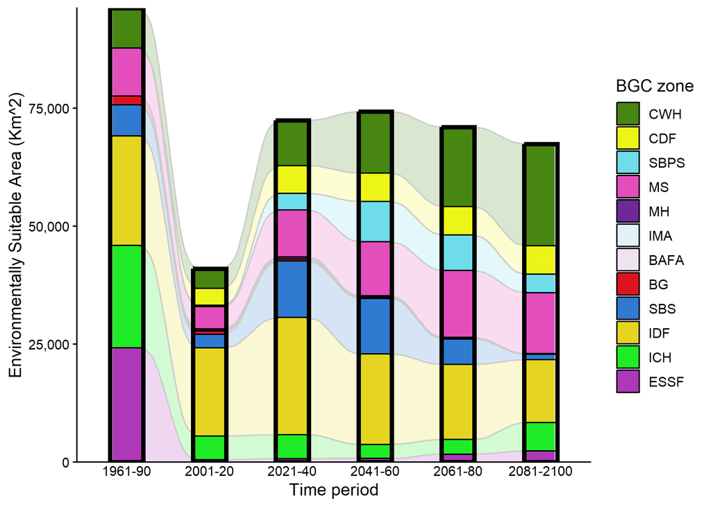

This figure shows the projected changes in Fd’s suitable area in BC (km<sup>2</sup>) over time by biogeoclimatic zone (colours) within the three representative site types/edatopes (tabs). The first time period shown on the left of each graph is the historical reference period (1961–1990), where environmental suitability is determined by expert ratings. Subsequent time periods are based on CCISS model projections incorporating environmental suitability (from the reference period) and future climate data. For future projected time periods, the relative areas of BGC zones remain static within the province (i.e., they are not shrinking or growing). Rather, this figure reflects changes in the projected spatial distribution of climate types that may be more or less suitable for the focal species, representing changes in suitable area across these static zones.

**Key to BGC zones:** [CCISS Documentation > Definitions](https://bcgov-ffec.ca/cciss-docs/Definitions.html#biogeoclimatic-ecosystem-classification-bec-codes)

Many mapped subzones within the Sub-Boreal Spruce (SBS) zone in the Skeena Region are projected to become warmer, shifting towards Interior Douglas-fir (IDF)-like climate or warmer and wetter, shifting towards Interior Cedar–Hemlock (ICH)-like climate in the future. These climates are suitable for Fd and **expand** the total suitable area for Fd. Similarly, on the Chilcotin Plateau Sub-Boreal Pine–Spruce (SBPS) units are projected to shift towards IDF-like climate. The Engelmann Spruce–Subalpine Fir (ESSF) occurs on all major mountains surrounding the interior plateau (found above the MS, SBS, ICH and BWBS zones) and historically supported small populations of Fd in the warmer ESSF subzones (e.g. ESSFdh1). Warming temperatures are the likely driver of **increases** in suitable area for Fd projected into the ESSF zone. Fd is also projected to become suitable in a greater portion of the Coastal Western Hemlock (CWH) zone, as this area becomes warmer and drier, shifting to climates of warmer/drier CWH and Coastal Douglas-fir (CDF) subzones which are climatically suitable to Fd.

The **loss** of environmentally suitable area in the IDF zone is driven by a shift to Bunchgrass (BG)-like climates, which does not support Fd.

These broad patterns are similar across the medium/mesic (C4) and poor/subxeric (B2) site types.

Note that the **D6 edatope** (wet rich sites) makes up a small area proportional to the total range of Fd in BC, an order of magnitude less than the area occupied by Fd on C4 or B2 sites. Historical suitability is low (E3) on most D6 sites, therefore decreases in suitability associated with the projection of warmer-climates often result in a loss of Fd suitability. The total area suitable to Fd is projected to decrease or be lost in the ESSF, IDF, and SBS, while there is an increased projected area in the CWH. It is also possible that these projected decreases in Fd suitability on wet rich sites are an artefact of the BGC projection method and site series crosswalk, with many fewer D6 sites containing Fd overall, compared to the C4 and B2 edatopes (see [CCISS tool documentation](https://bcgov-ffec.ca/cciss-docs/Methods.html) for more information).

**Biotic factors**

Douglas-fir beetle (*Dendroctonus pseudotsugae*) is one of the primary killers of mature Douglas-fir (Fd) in BC and usually attacks weakened or dying trees. Occasionally the beetle populations increase to the extent that it infests and kills large numbers of healthy trees (Douglas-Fir Beetle, 2025). It is most common in BC’s interior and less common in coastal forests where it rarely causes the large-scale damage seen in the interior. Trees are killed when the flow of food and water between the roots and needles is blocked by feeding larvae and by dead sapwood cells killed by the blue-stain fungus carried by the Douglas-fir beetle adults (Burleigh et al., 2014).

Fd is also attacked by western spruce budworm (*Choristoneura occidentalis*), a native defoliator found southern BC in the coast, montane and Columbia forest types. Population levels periodically reach outbreaks which can last up to 25 years (Western Spruce Budworm, 2025). When trees are stressed they are more likely to die. Repeated budworm defoliation causes tree mortality over large areas. Sustained attack results in complete defoliation in four to five years. Once an infestation has subsided, surviving trees take several years to regain full foliage and resume growth. Successive years of defoliation in stands may predispose trees to other insects and pathogens such as bark beetles and root disease.

Douglas-fir tussock moth (*Orgyia pseudotsugata*) another is a defoliator of concern, found at low elevations in the warm dry areas of the Southern Interior and occasionally on the south coast. Defoliated trees may die after one or more years of severe defoliation. Douglas-fir tussock moth outbreaks can cause extensive mortality of interior Fd (Douglas-Fir Tussock Moth, 2025).

In coastal populations, Fd is affected by Swiss needle cast (*Nothophaeocryptopus gaeumannii*) is a fungus that causes a major foliar disease (Swiss Needle Cast, 2025). Swiss needle cast has emerged as a serious concern in recent decades, with increased incidence due to warmer winters and increased spring moisture. It often affects young stands of Fd leading to premature foliar drop, loss of growth and occasionally mortality.

Finally, root and butt rots (for example, red ring rot [*Phellinus pini*], laminated root rot [*Coniferiporia sulphurascens*], and Armillaria root disease [*Armillaria ostoyae*]) are a major and increasing concern for Fd.

For more information see the [Forest Guide to Tree Health](https://www2.gov.bc.ca/assets/gov/farming-natural-resources-and-industry/forestry/forest-health/forest-health-docs/field_guide_to_forest_damage_in_bc_web.pdf). To view forest health risk across BGC subzone by tree species and biotic factor see the “Forest Health” tab of the [By-BEC Portal](https://thebeczone.ca/shiny/bybecmap/).

**Climate change and drought**

Higher summer temperatures and drought are causing reduced Fd growth, increased mortality and susceptibility to pests and pathogens. Increased Fd mortality has been observed following periods of prolonged drought and warming, associated with decreasing summer available soil water and increasing summer temperature and rising vapour pressure deficit (for example in western Oregon, Cline et al. (2025)).

These trends are driven by specific physiological vulnerabilities. Fd has a large foliage area and fairly high water consumption at maturity compared to co-occurring conifers, making it vulnerable to a warmer drier climate (Leuschner & Meinzer, 2024). Additionally, evidence suggests that the root system of juvenile Fd is highly drought-sensitive, while drought susceptibility decreases with age, when root penetration is deeper (Leuschner & Meinzer, 2024). Tap root growth of Fd seedlings and saplings is slow, and root system remains shallow, meaning young plants are susceptible to desiccation. Consequently, seedlings may face high drought induced mortality in large open gaps or when planted on clear cuts. To mitigate these vulnerabilities, research from BC’s coastal forests suggests that a lower planting density improved the drought tolerance of Fd (Damen et al., 2025; Lukose et al., 2025).

Numerous dendrochronological studies have demonstrated that reduced Fd growth is linked to increased temperature and vapour pressure deficit (Gazol et al., 2022; Leuschner & Meinzer, 2024; Restaino et al., 2016). During severe droughts, annual radial growth can be reduced by 30 %, or more and consecutive droughts increase the negative impact on growth (Charlet De Sauvage et al., 2023; Montwé et al., 2015; Sergent et al., 2014). The hot droughts of 2015 and 2021 in the Pacific Northwest have led to growth decline, crown damage, and mortality of Fd in low-elevation regions, often linked to fungal and insect infestations (Leuschner & Meinzer, 2024).

In southern and lowland areas Fd growth is expected to slow and pathogen/insect attack and mortality will increase (Leuschner & Meinzer, 2024). On the coast, warming winters may increase susceptibility to fungal attack (notably Swiss needle cast), causing defoliation, growth decline and mortality. Conversely, climate warming will likely promote Fd growth in the cooler and wetter areas of its range.

**Works Cited**

Adams, H. D., & Kolb, T. E. (2005). Tree growth response to drought and temperature in a mountain landscape in northern Arizona, USA. *Journal of Biogeography*, *32*(9), 1629–1640. https://doi.org/10.1111/j.1365-2699.2005.01292.x

Burleigh, J., Ebata, T., White, K. J., Rusch, D., & Kope, H. (2014). *Field Guide to Forest Damage in British Columbia* (No. 17). British Columbia Ministry of Forests Lands; Natural Resource Operations.

Case, M. J., & Peterson, D. L. (2005). Fine-scale variability in growthclimate relationships of Douglas-fir, North Cascade Range, Washington. *Canadian Journal of Forest Research*, *35*(11), 2743–2755. https://doi.org/10.1139/x05-191

Charlet De Sauvage, J., Bugmann, H., Bigler, C., & Lévesque, M. (2023). Species diversity and competition have minor effects on the growth response of silver fir, European larch and Douglas fir to drought. *Agricultural and Forest Meteorology*, *341*, 109664. https://doi.org/10.1016/j.agrformet.2023.109664

Cline, S. P., Lee, E. H., Waschmann, R. S., Bollman, M. A., & Beedlow, P. A. (2025). Warming temperatures and decreasing soil moisture are increasing tree mortality in mature Douglas-fir forests of western Oregon, USA. *Agricultural and Forest Meteorology*, *372*, 110681. https://doi.org/10.1016/j.agrformet.2025.110681

Damen, F., Aitken, S., Degner, J., & Montwé, D. (2025). Drought resilience of coastal Douglas-fir is influenced by competition but not genetic selection. *Forest Ecology and Management*, *578*, 122488. https://doi.org/10.1016/j.foreco.2024.122488

*Douglas-fir beetle*. (2025). Government of British Columbia. https://www2.gov.bc.ca/gov/content/industry/forestry/managing-our-forest-resources/forest-health/forest-pests/bark-beetles/douglas-fir-beetle

*Douglas-fir tussock moth*. (2025). Government of British Columbia. https://www2.gov.bc.ca/gov/content/industry/forestry/managing-our-forest-resources/forest-health/forest-pests/defoliators/douglas-fir-tussock-moth

Egan, B. (1999). *Ecology of the Coastal Western Hemlock Zone*. Crown Publications, BC Ministry of Forests.

Gazol, A., Valeriano, C., Cantero, A., Vergarechea, M., & Camarero, J. J. (2022). Douglas Fir Growth Is Constrained by Drought: Delineating the Climatic Limits of Timber Species under Seasonally Dry Conditions. *Forests*, *13*(11), 1796. https://doi.org/10.3390/f13111796

Griesbauer, H. P., & Green, D. S. (2010). Regional and ecological patterns in interior Douglas-fir climate–growth relationships in British Columbia, Canada. *Canadian Journal of Forest Research*, *40*(2), 308–321. https://doi.org/10.1139/X09-197

Klinka, K., Worrall, J., Skoda, L., Varga, P., & Chourmouzis, C. (2000). *The Distribution and Synopsis of Ecological and Silvical Characteristics of Tree Species of British Columbia*. Forest Sciences Department, University of British Columbia. https://doi.org/10.14288/1.0107280

Leuschner, C., & Meinzer, F. C. (2024). Drought resistance and drought adaptation of Douglas-fir (Pseudotsuga menziesii) – A review. *Perspectives in Plant Ecology, Evolution and Systematics*, *65*, 125829. https://doi.org/10.1016/j.ppees.2024.125829

Lukose, S., Omari, K., & Pinno, B. D. (2025). Mixing tree species and density management to reduce drought susceptibility in coastal plantation forests of British Columbia. *Forest Ecology and Management*, *598*, 123235. https://doi.org/10.1016/j.foreco.2025.123235

Mahony, C. R., Wang, T., Hamann, A., & Cannon, A. J. (2022). A global climate model ensemble for downscaled monthly climate normals over North America. *International Journal of Climatology*, *42*(11), 5871–5891. https://doi.org/doi.org/10.1002/joc.7566

Montwé, D., Spiecker, H., & Hamann, A. (2015). Five decades of growth in a genetic field trial of Douglas-fir reveal trade-offs between productivity and drought tolerance. *Tree Genetics & Genomes*, *11*(2), 29. https://doi.org/10.1007/s11295-015-0854-1

Restaino, C. M., Peterson, D. L., & Littell, J. (2016). Increased water deficit decreases Douglas fir growth throughout western US forests. *Proceedings of the National Academy of Sciences*, *113*(34), 9557–9562. https://doi.org/10.1073/pnas.1602384113

Sergent, A.-S., Bréda, N., Sanchez, L., Bastein, J.-C., & Rozenberg, P. (2014). Coastal and interior Douglas-fir provenances differ in growth performance and response to drought episodes at adult age. *Annals of Forest Science*, *71*(6), 709–720. https://doi.org/10.1007/s13595-014-0393-1

*Swiss needle cast*. (2025). Government of British Columbia. https://www2.gov.bc.ca/gov/content/industry/forestry/managing-our-forest-resources/forest-health/pathogens/foliar-pathogens/swiss-needle-cast

Watson, E., & Luckman, B. H. (2002). The dendroclimatic signal in Douglas-fir and ponderosa pine tree-ring chronologies from the southern Canadian Cordillera. *Canadian Journal of Forest Research*, *32*(10), 1858–1874. https://doi.org/10.1139/x02-096

*Western spruce budworm*. (2025). Government of British Columbia. https://www2.gov.bc.ca/gov/content/industry/forestry/managing-our-forest-resources/forest-health/forest-pests/defoliators/western-spruce-budworm

**Reference materials** [CCISS tool](https://bcgov-ffec.ca/cciss/) [Douglas-fir - in the BC Tree Species Compendium](https://www2.gov.bc.ca/gov/content/industry/forestry/managing-our-forest-resources/silviculture/stocking-standards/tree-species-compendium-index/douglas-fir) [Forest Guide to Tree Health](https://www2.gov.bc.ca/assets/gov/farming-natural-resources-and-industry/forestry/forest-health/forest-health-docs/field_guide_to_forest_damage_in_bc_web.pdf)